# Group 1 Midterm

Evelyn Campo, Xiao Qi, Nusrat Prithee, Roman

today

Importing the Dataset assigning “NA” to all blank cells

```r
tvdata <- read.csv("tv_shows.csv", header=T, na.strings=c("","NA"))
```

Cleaning the Dataset

```r
tvdata$IMDb<-gsub("/10","",as.character(tvdata$IMDb)) #We had to delete the character /10 on every observation
tvdata$Rotten.Tomatoes<-gsub("/100","",as.character(tvdata$Rotten.Tomatoes)) #We had to delete the character /100 on every observation
tvdata$IMDb<-as.double(tvdata$IMDb) #as.double is a generic function. It is identical to as. numeric
tvdata$Rotten.Tomatoes<-as.double(tvdata$Rotten.Tomatoes) #as.double is a generic function. It is identical to as. numeric
tvdata = select(tvdata, -X, -ID, -Type) #This variables aren't of our interest

str(tvdata)
View(tvdata)
```

Counting missing values

```r
sum(is.na(tvdata)) #Total NA
mean(is.na(tvdata))

#NA per variables
sum(is.na(tvdata$Title))
sum(is.na(tvdata$Year))
sum(is.na(tvdata$Age))
sum(is.na(tvdata$IMDb))
sum(is.na(tvdata$`Rotten Tomatoes`))
sum(is.na(tvdata$Netflix))
sum(is.na(tvdata$Hulu))
sum(is.na(tvdata$`Prime Video`))
sum(is.na(tvdata$`Disney+`))
```

Age has the most missing values in the Dataset, and IMDb is the other variable with NA values.

Streaming platforms into as.factor()

```r
tvdata$Netflix <- as.factor(tvdata$Netflix)
tvdata$Hulu <- as.factor(tvdata$Hulu)
tvdata$Prime.Video <- as.factor(tvdata$Prime.Video)
tvdata$Disney. <- as.factor(tvdata$Disney.)
```

The streaming platforms are categorical. 1 represents if the TV show is found on their platform otherwise 0.

Just undertanding a lilttle more about streaming platform variables and age

```r
print("Age:")
table(tvdata$Age)
print("Netflix:")
table(tvdata$Netflix)
print("Hulu:")
table(tvdata$Hulu)
print("Prime Video:")
table(tvdata$Prime.Video)
print("Disney:")
table(tvdata$Disney.)
```

What are the most targeted age groups for the TV shows by Netflix, Hulu, Prime, disney Video?

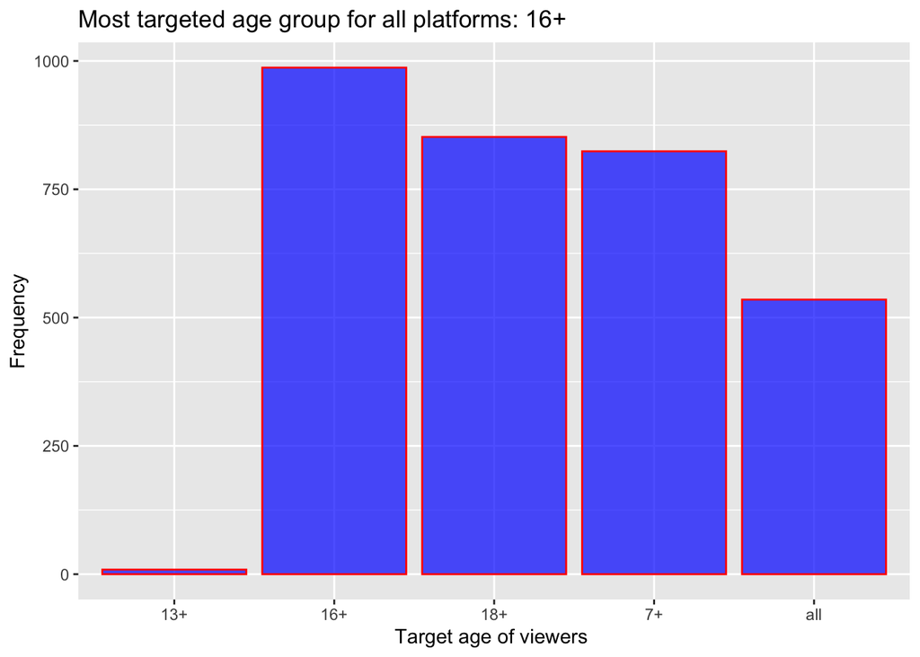

```r
print("Age:")
table(tvdata$Age)
prop.table(table(tvdata$Age))

ggplot(data = na.omit(tvdata), aes(Age)) +
  geom_bar(col="red",
                 fill="blue",
                 alpha = .7) + # opacity
  labs(title="Most targeted age group for all platforms: 16+ ") +
  labs(x="Target age of viewers ", y="Frequency")
```

```r
#I am taking this graph from above since it works for this question
```

people who are 16 and older are the most targeted age groups for the tv shows among the all steamming platfrom.

.Which year published the highest number of TV shows?

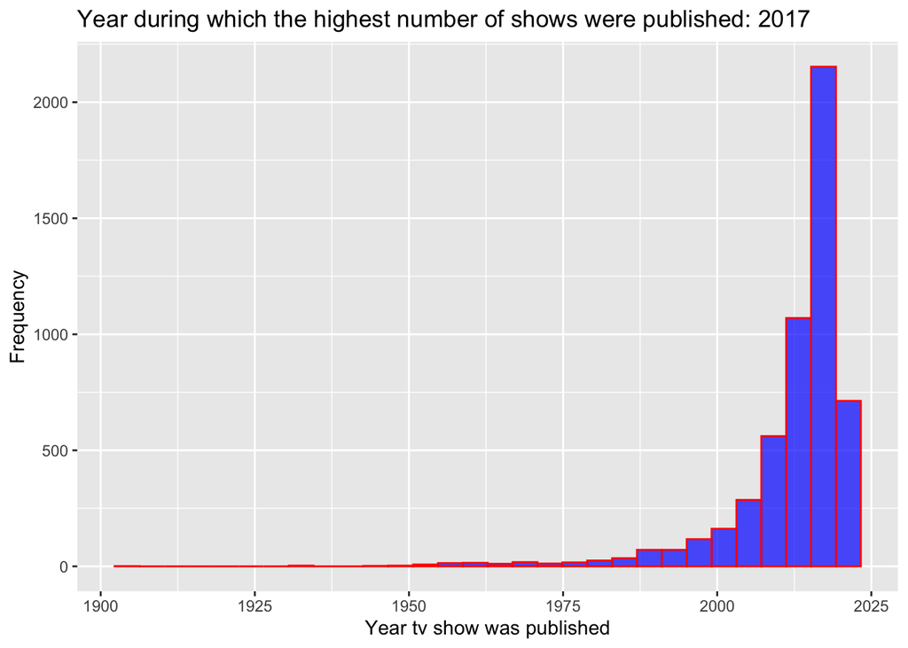

```r
print("Year:")
table(tvdata$Year)
library(ggplot2)
ggplot(data=tvdata, aes(Year)) +
  geom_histogram(bins = 30,
                 col="red",
           fill="blue",
           alpha = .7) + # opacity
  labs(title="Year during which the highest number of shows were published: 2017") +
  labs(x="Year tv show was published", y="Frequency")
```

```r
#I am replacing the prevous code with the graphs from above to keep the same formatting
```

Normality check of Variables

```r
netflixtv <- subset(tvdata, Netflix==1)
hulutv <- subset(tvdata, Hulu==1)
primetv <- subset(tvdata, Prime.Video==1)
disneytv <- subset(tvdata, Disney.==1)
```

Which streaming platform has the highest average rating (according to Rotten Tomatoes and IMDb)?

```r
net_rating<-t.test(netflixtv$IMDb,netflixtv$Rotten.Tomatoes)
net_rating
hulu_rating<-t.test(hulutv$IMDb,hulutv$Rotten.Tomatoes)
hulu_rating
prime_rating<-t.test(primetv$IMDb,primetv$Rotten.Tomatoes)
prime_rating
disney_rating<-t.test(disneytv$IMDb,disneytv$Rotten.Tomatoes)
disney_rating
```

Prime Videos has the highest average Imdb rating which is 7.152538. Also, Netflix has the highest average RTT rating which is 53.559107

Normality check for the variable IMDb and Rotten.Tomatoes

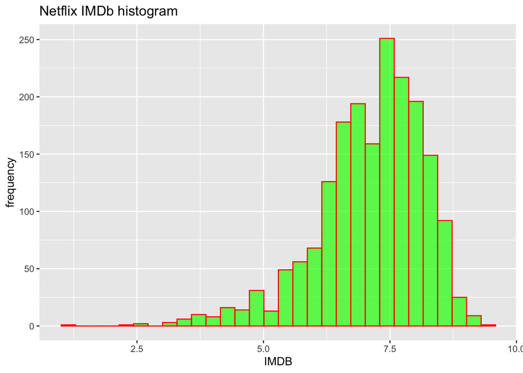

```r
shapiro.test(netflixtv$IMDb)
shapiro.test(netflixtv$Rotten.Tomatoes)

library(ggplot2)
ggplot(data=netflixtv,aes(x=IMDb,)) +
geom_histogram(col="red",
               fill="green",
               alpha = .7) +
labs(title="Netflix IMDb histogram") +
labs(x="IMDB", y="frequency")
```

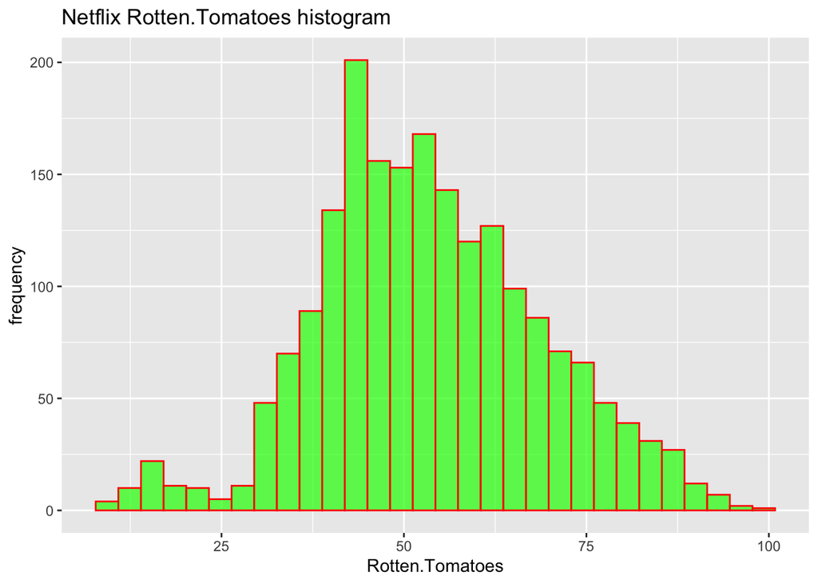

```r
ggplot(data=netflixtv,aes(x=Rotten.Tomatoes,)) +
geom_histogram(col="red",
               fill="green",
               alpha = .7) +
labs(title="Netflix Rotten.Tomatoes histogram") +
labs(x="Rotten.Tomatoes", y="frequency")
```

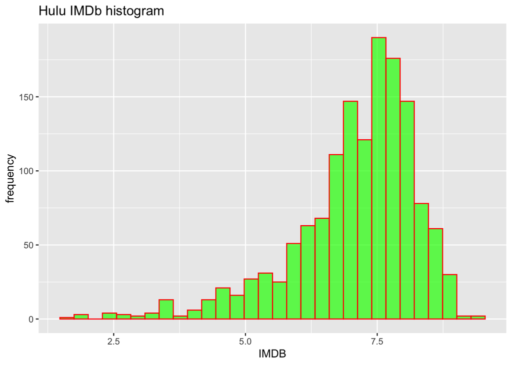

```r
shapiro.test(hulutv$IMDb)
shapiro.test(hulutv$Rotten.Tomatoes)

library(ggplot2)
ggplot(data=hulutv,aes(x=IMDb,)) +
geom_histogram(col="red",
               fill="green",
               alpha = .7) +
labs(title="Hulu IMDb histogram") +
labs(x="IMDB", y="frequency")
```

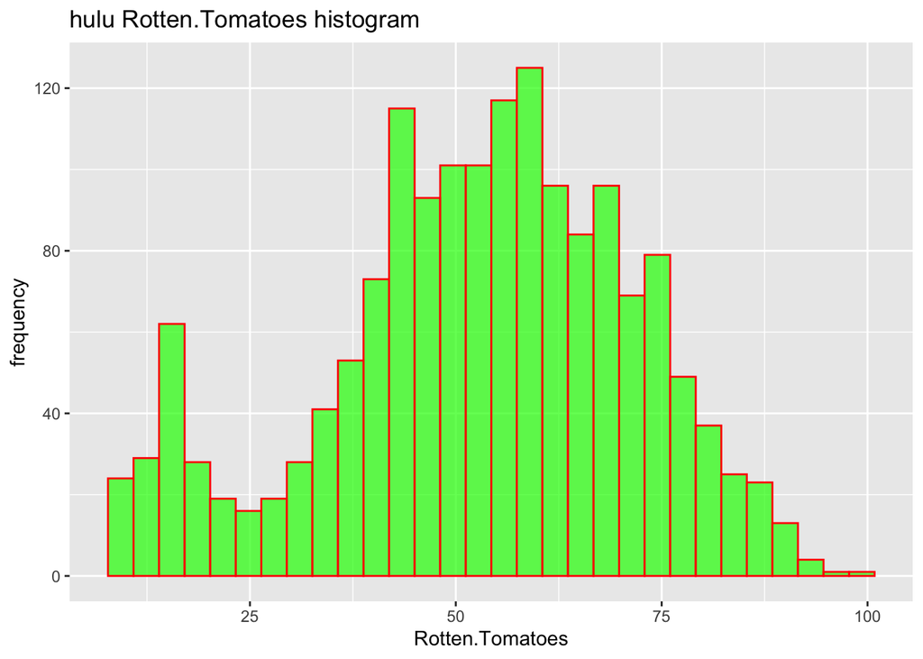

```r
ggplot(data=hulutv,aes(x=Rotten.Tomatoes,)) +
geom_histogram(col="red",
               fill="green",
               alpha = .7) +
labs(title="hulu Rotten.Tomatoes histogram") +
labs(x="Rotten.Tomatoes", y="frequency")
```

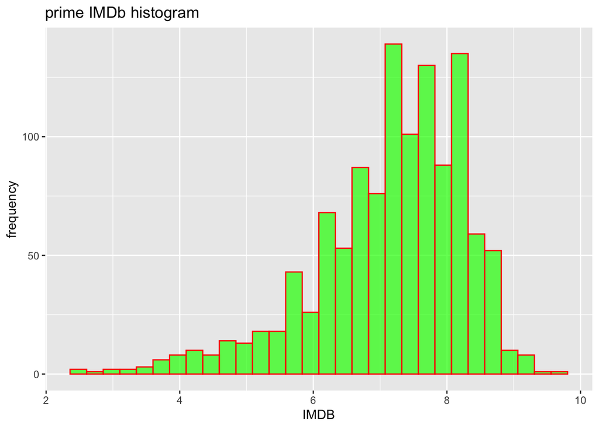

```r
shapiro.test(primetv$IMDb)
shapiro.test(primetv$Rotten.Tomatoes)
library(ggplot2)
ggplot(data=primetv,aes(x=IMDb,)) +
geom_histogram(col="red",
               fill="green",
               alpha = .7) +
labs(title="prime IMDb histogram") +
labs(x="IMDB", y="frequency")
```

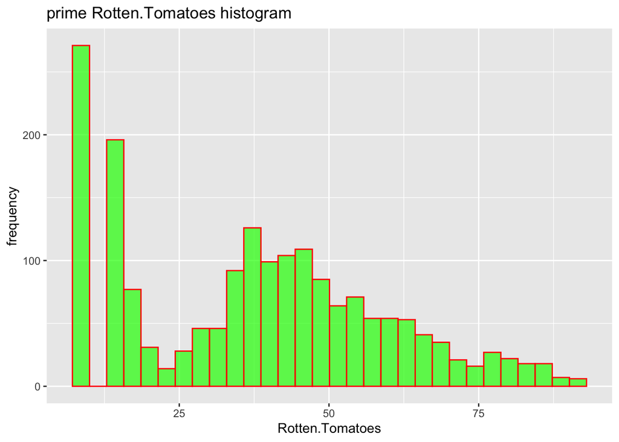

```r
ggplot(data=primetv,aes(x=Rotten.Tomatoes,)) +
geom_histogram(col="red",
               fill="green",
               alpha = .7) +
labs(title="prime Rotten.Tomatoes histogram") +
labs(x="Rotten.Tomatoes", y="frequency")
```

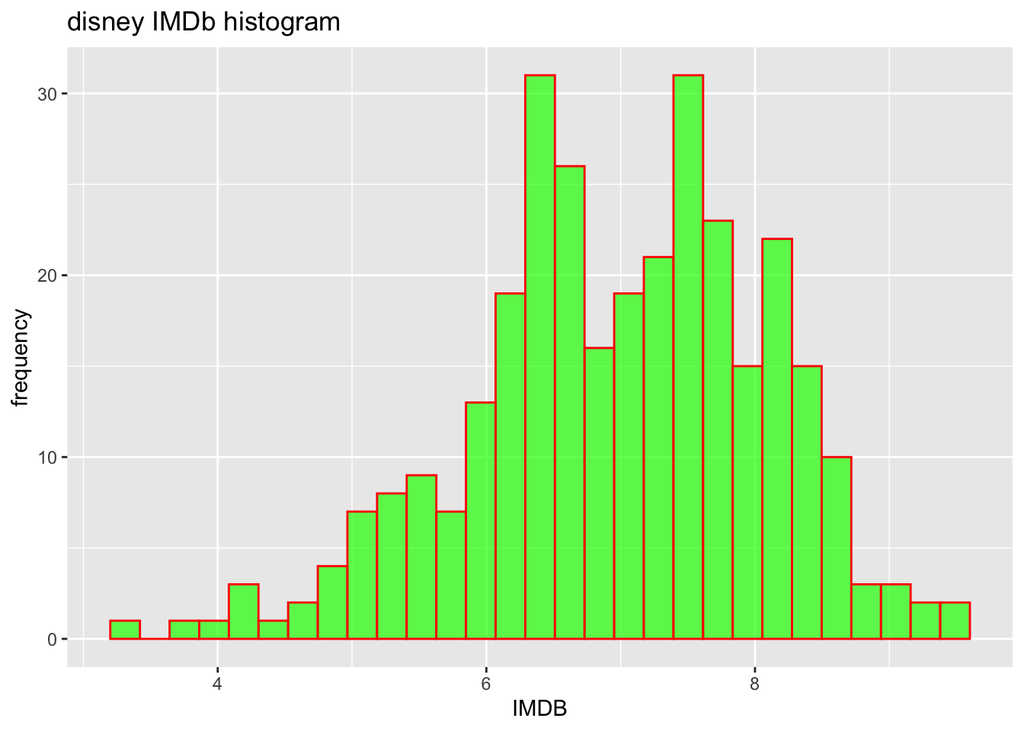

```r
shapiro.test(disneytv$IMDb)
shapiro.test(disneytv$Rotten.Tomatoes)
library(ggplot2)
ggplot(data=disneytv,aes(x=IMDb,)) +
geom_histogram(col="red",
               fill="green",
               alpha = .7) +
labs(title="disney IMDb histogram") +
labs(x="IMDB", y="frequency")
```

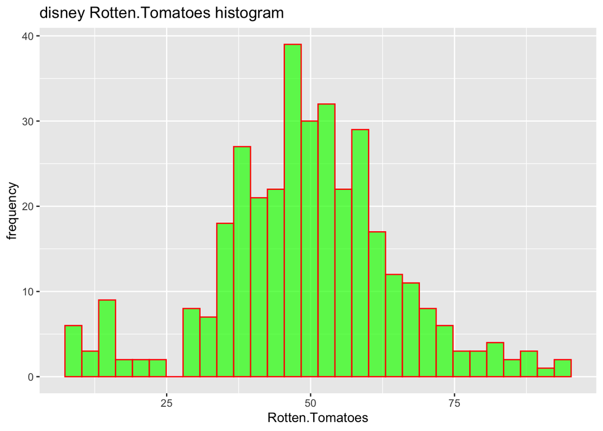

```r
ggplot(data=disneytv,aes(x=Rotten.Tomatoes,)) +
geom_histogram(col="red",
               fill="green",
               alpha = .7) +
labs(title="disney Rotten.Tomatoes histogram") +
labs(x="Rotten.Tomatoes", y="frequency")
```

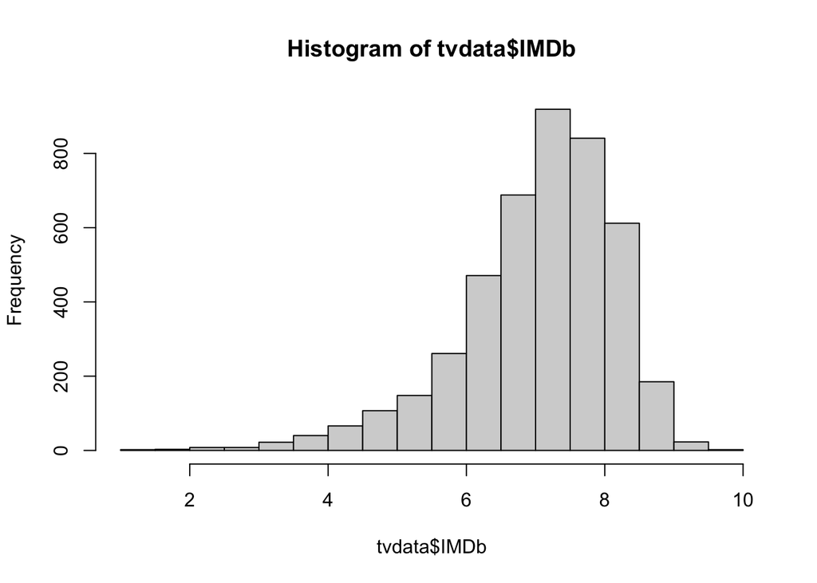

```r
hist(tvdata$IMDb,breaks=20)
```

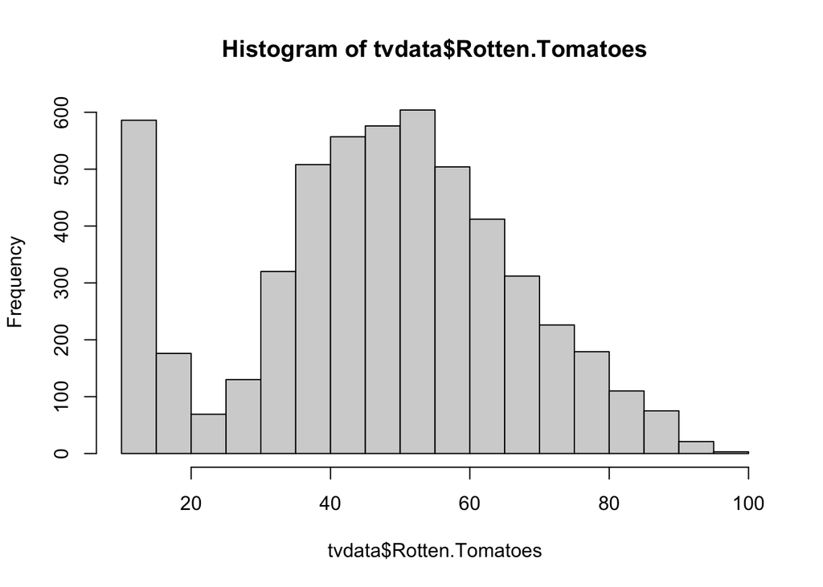

```r
hist(tvdata$Rotten.Tomatoes,breaks=20)
```

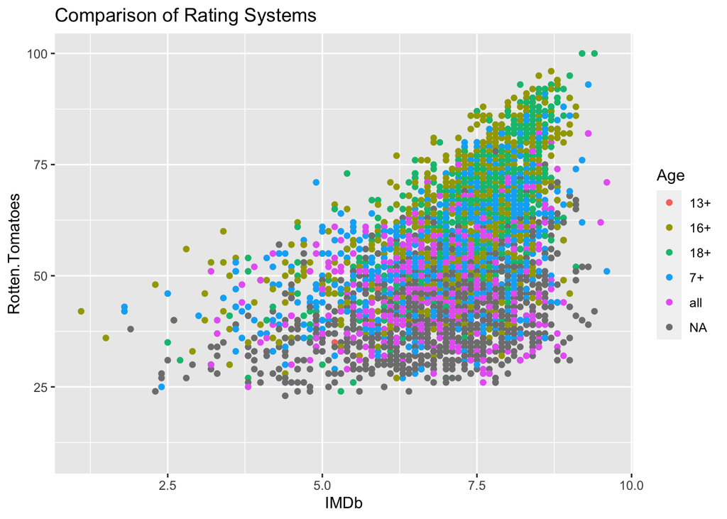

```r
ggplot(data=tvdata, aes(x=IMDb, y=Rotten.Tomatoes, col=Age)) + geom_point() + ggtitle("Comparison of Rating Systems")
```

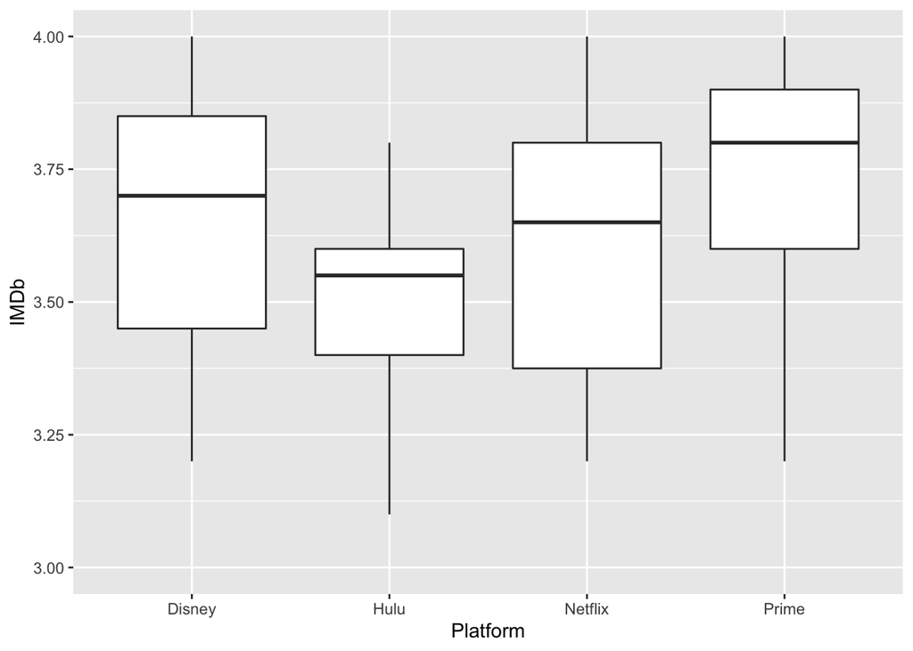

```r
netflixtv <- subset(tvdata, Netflix==1)
netflixtv$Platform <- "Netflix"
hulutv <- subset(tvdata, Hulu==1)
hulutv$Platform <- "Hulu"
primetv <- subset(tvdata, Prime.Video==1)
primetv$Platform <- "Prime"
disneytv <- subset(tvdata, Disney.==1)
disneytv$Platform <- "Disney"
plot.data <- rbind(netflixtv, hulutv, primetv, disneytv)
ggplot(plot.data, aes(x=Platform, y=IMDb)) + geom_boxplot(outlier.shape = NA)+
  scale_y_continuous(limits = (3:10))
```

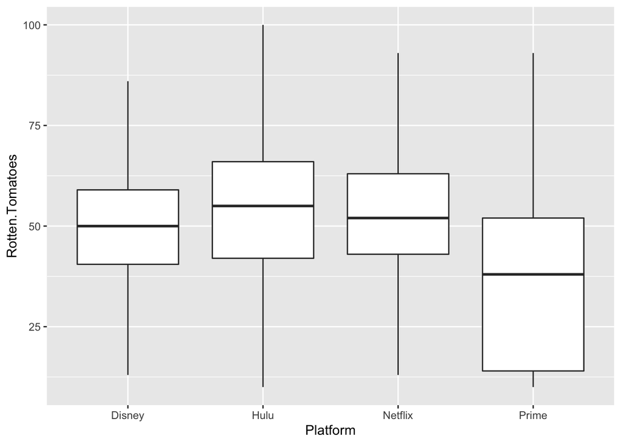

```r
ggplot(plot.data, aes(x=Platform, y=Rotten.Tomatoes)) + geom_boxplot(outlier.shape = NA)
```

```r
testfit1 <- lm(IMDb ~ Rotten.Tomatoes*Platform,data=plot.data)
summary(testfit1)
testfit2 <- lm(IMDb ~ Rotten.Tomatoes+Platform,data=plot.data)
summary(testfit2)
testfit3 <- lm(IMDb ~ Rotten.Tomatoes,data=plot.data)
summary(testfit3)
```

```r
contable1= table(netflixtv$Age, netflixtv$IMDb)
contable1
chitest1 = chisq.test(contable1)
chitest1

contable2 = table(netflixtv$Age, netflixtv$Rotten.Tomatoes)
contable2
chitest2 = chisq.test(contable2)
chitest2
```

```r
contable3= table(hulutv$Age, hulutv$IMDb)
contable3
chitest3 = chisq.test(contable3)
chitest3

contable4 = table(hulutv$Age, hulutv$Rotten.Tomatoes)
contable4
chitest4 = chisq.test(contable4)
chitest4
```

```r
contable5= table(primetv$Age, primetv$IMDb)
contable5
chitest5 = chisq.test(contable5)
chitest5

contable6 = table(primetv$Age, primetv$Rotten.Tomatoes)
contable6
chitest6 = chisq.test(contable6)
chitest6
```

```r
contable7= table(disneytv$Age, disneytv$IMDb)
contable7
chitest7 = chisq.test(contable7)
chitest7

contable8 = table(disneytv$Age, disneytv$Rotten.Tomatoes)
contable8
chitest8= chisq.test(contable8)
chitest8
```

This step is to clear data, change some string data to number and some to factor.

```r
tvdata1 <- read.csv("tv_shows.csv", header=T, na.strings=c("","NA"))
tvdata1$IMDb<-gsub("/10","",as.character(tvdata1$IMDb))
tvdata1$Rotten.Tomatoes<-gsub("/100","",as.character(tvdata1$Rotten.Tomatoes))
tvdata1$IMDb<-as.double(tvdata1$IMDb)
tvdata1$Rotten.Tomatoes<-as.double(tvdata1$Rotten.Tomatoes)

# total_plt <- tvdata$Netflix + tvdata$Hulu + tvdata$Prime.Video + tvdata$Disney.
# tvdata <- cbind(tvdata, total_plt)

tvdata1$Netflix = factor(tvdata1$Netflix)
tvdata1$Hulu = factor(tvdata1$Hulu)
tvdata1$Prime.Video = factor(tvdata1$Prime.Video)
tvdata1$Disney. = factor(tvdata1$Disney.)
tvdata1$Age = factor(tvdata1$Age)

str(tvdata1)
#View(tvdata)
```

To analyze the score relationships between two platforms, we need to drop the rows that have no IMDb scores and no Rotten.Tomatoes scores. Meanwhile, the column of X, ID, Title and Type are useless, so we also drop these columns.

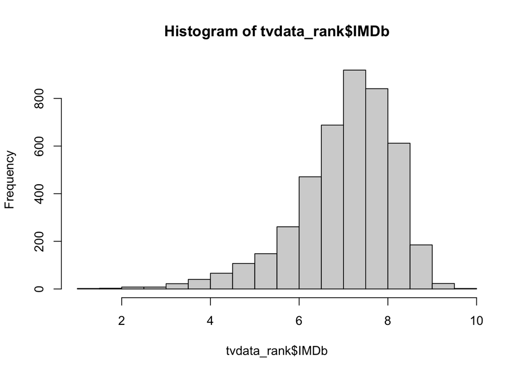

```r
tvdata_rank = subset(tvdata1, (!is.na(IMDb)) & (!is.na(Rotten.Tomatoes)))
tvdata_rank = subset(tvdata_rank, select = -c(X, ID, Title, Type))
#str(tvdata_rank)
# We've already done the above code
hist(tvdata_rank$IMDb,breaks=20)
```

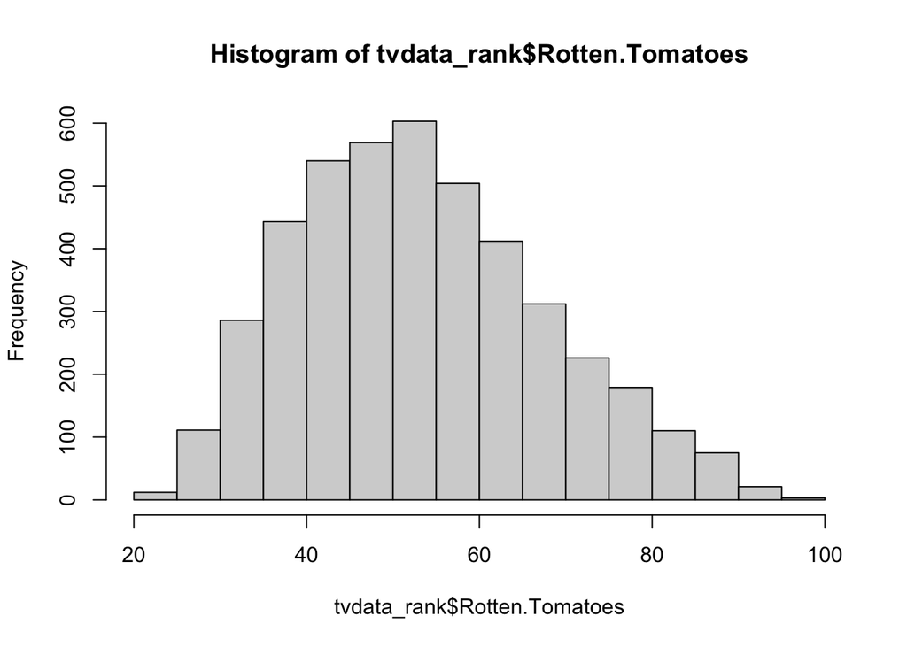

```r
hist(tvdata_rank$Rotten.Tomatoes,breaks=20)
```

Make a pairs() plot with all the variables (quantitative and qualitative).

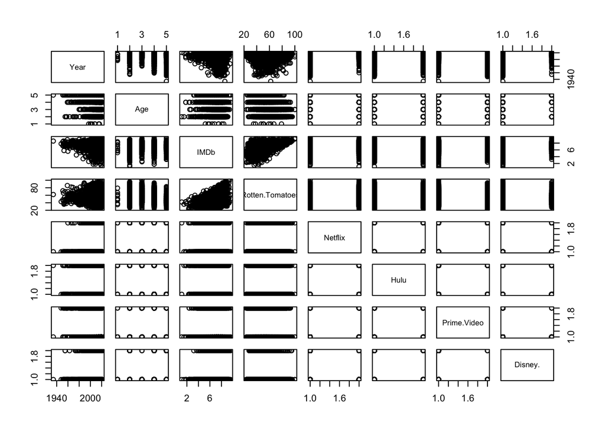

```r
loadPkg("lattice") # lattice and ggplot2 combined allow us to use the "pairs" function below
pairs(tvdata_rank)
```

Make a corrplot() with only the numerical variables.

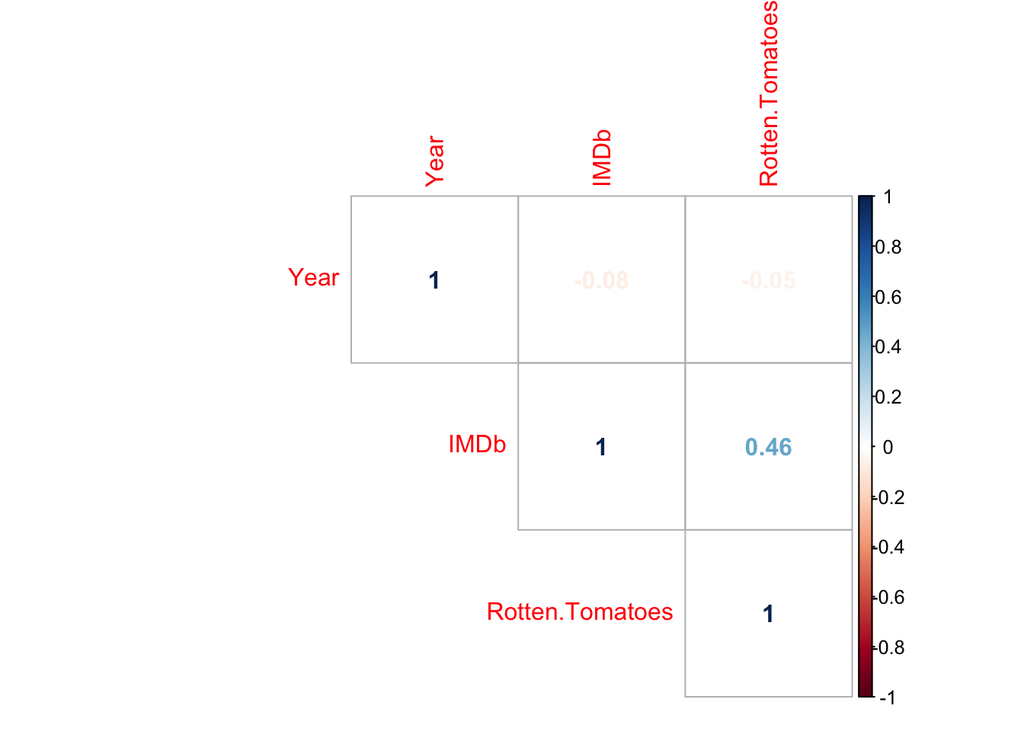

```r
loadPkg("corrplot")
tvdata_rank_num = subset(tvdata_rank, select = -c(Age, Netflix, Hulu, Prime.Video, Disney.))

cor_tvdata = cor(tvdata_rank_num)

corrplot(cor_tvdata, method = "number", type="upper")
```

```r
# corrplot.mixed(cor_tvdata)
```

By using the variable Rotten.Tomatoes only, build a linear model with 1 independent variable to predict the IMDb.

```r
model1 = lm(IMDb ~ Rotten.Tomatoes, data=tvdata_rank)
sum_md1 = summary(model1) # also for later use on inline codes
sum_md1
```

```
##
## Call:
## lm(formula = IMDb ~ Rotten.Tomatoes, data = tvdata_rank)
##
## Residuals:
##    Min     1Q Median     3Q    Max
## -5.562 -0.495  0.087  0.628  2.746
##
## Coefficients:
##                 Estimate Std. Error t value Pr(>|t|)
## (Intercept)      5.15419    0.05785    89.1   <2e-16 ***
## Rotten.Tomatoes  0.03590    0.00104    34.6   <2e-16 ***
## ---
## Signif. codes:  0 '***' 0.001 '**' 0.01 '*' 0.05 '.' 0.1 ' ' 1
##
## Residual standard error: 0.989 on 4404 degrees of freedom
## Multiple R-squared:  0.213,  Adjusted R-squared:  0.213
## F-statistic: 1.19e+03 on 1 and 4404 DF,  p-value: <2e-16
```

```r
xkabledply(model1, title = paste("Model (num):", format(formula(model1)) ) )
```

Model (num): IMDb ~ Rotten.Tomatoes

|  | Estimate | Std. Error | t value | Pr(>\|t\|) |
| --- | --- | --- | --- | --- |
| (Intercept) | 5.1542 | 0.0579 | 89.1 | 0 |
| Rotten.Tomatoes | 0.0359 | 0.0010 | 34.6 | 0 |

Because there is only a weak correlation, I try to add the other variables into the model. Below is the result:

```r
model2 = lm(IMDb ~ ., data=tvdata_rank)
sum_md2 = summary(model2) # also for later use on inline codes
sum_md2
```

We can find that the adjusted correlation coefficient increases, but some variables are not significant, so try to drop it.

```r
table(tvdata_rank$Age)
```

The result is that for age13+, there are only 9 shows. Too little sample cause a large p-value. So we need to drop the factor of Age13+. We also drop Netflix, Prime.Video, Disney., because the p-values of these variables are not significant.

```r
tvdata_rank_no13 <- subset(tvdata_rank, Age!="13+")
tvdata_rank_no13 = subset(tvdata_rank_no13, select = -c(Netflix, Prime.Video, Disney.))
```

And then me make the third model as follow.

```r
model3 = lm(IMDb ~ ., data=tvdata_rank_no13)
sum_md3 = summary(model3) # also for later use on inline codes
sum_md3
```

```r
#vif_md3 = faraway::vif(model3)
#vif_md3

xkabledply(model3, title = paste("Model (num):", format(formula(model3)) ) )
```

Model (num): IMDb ~ Year + Age + Rotten.Tomatoes + Hulu

|  | Estimate | Std. Error | t value | Pr(>\|t\|) |
| --- | --- | --- | --- | --- |
| (Intercept) | 18.5224 | 3.4722 | 5.335 | 0.0000 |
| Year | -0.0068 | 0.0017 | -3.968 | 0.0001 |
| Age18+ | -0.0649 | 0.0442 | -1.468 | 0.1423 |
| Age7+ | -0.0572 | 0.0450 | -1.271 | 0.2038 |
| Ageall | 0.0315 | 0.0545 | 0.577 | 0.5639 |
| Rotten.Tomatoes | 0.0420 | 0.0013 | 32.300 | 0.0000 |
| Hulu1 | -0.2002 | 0.0355 | -5.633 | 0.0000 |

```r
xkablevif(model3)
```

VIFs of the model

| Age18+ | Age7+ | Ageall | Hulu1 | Rotten.Tomatoes | Year |
| --- | --- | --- | --- | --- | --- |
| 1.17 | 1.42 | 1.44 | 1.54 | 1.2 | 1.1 |

```r
# aovresult <- anova(model1, model2, model3)
# aovresult
```

This is an Error because “models were not all fitted to the same size of dataset”, so we redo the simple linear regression using tvdata_rank_no13 as model4.

```r
model4 = lm(IMDb ~ Rotten.Tomatoes, data=tvdata_rank_no13)
sum_md4 = summary(model4) # also for later use on inline codes
sum_md4
```

```
##
## Call:
## lm(formula = IMDb ~ Rotten.Tomatoes, data = tvdata_rank_no13)
##
## Residuals:
##    Min     1Q Median     3Q    Max
## -5.396 -0.459  0.075  0.581  2.811
##
## Coefficients:
##                 Estimate Std. Error t value Pr(>|t|)
## (Intercept)       4.7863     0.0709    67.5   <2e-16 ***
## Rotten.Tomatoes   0.0407     0.0012    34.0   <2e-16 ***
## ---
## Signif. codes:  0 '***' 0.001 '**' 0.01 '*' 0.05 '.' 0.1 ' ' 1
##
## Residual standard error: 0.934 on 3196 degrees of freedom
## Multiple R-squared:  0.266,  Adjusted R-squared:  0.266
## F-statistic: 1.16e+03 on 1 and 3196 DF,  p-value: <2e-16
```

```r
xkabledply(model4, title = paste("Model (num):", format(formula(model4)) ) )
```

Model (num): IMDb ~ Rotten.Tomatoes

|  | Estimate | Std. Error | t value | Pr(>\|t\|) |
| --- | --- | --- | --- | --- |
| (Intercept) | 4.7863 | 0.0709 | 67.5 | 0 |
| Rotten.Tomatoes | 0.0407 | 0.0012 | 34.0 | 0 |

The concepts above can be extended naturally to models with interactions between numeric and factor variables.

```r
model5 = lm(IMDb ~ . + Rotten.Tomatoes:Age, data=tvdata_rank_no13)
sum_md5 = summary(model5) # also for later use on inline codes
sum_md5
```

```
##
## Call:
## lm(formula = IMDb ~ . + Rotten.Tomatoes:Age, data = tvdata_rank_no13)
##
## Residuals:
##    Min     1Q Median     3Q    Max
## -5.460 -0.457  0.069  0.579  2.788
##
## Coefficients:
##                        Estimate Std. Error t value Pr(>|t|)
## (Intercept)            20.68621    3.51095    5.89  4.2e-09 ***
## Year                   -0.00781    0.00174   -4.49  7.3e-06 ***
## Age18+                 -0.45763    0.20041   -2.28   0.0225 *
## Age7+                  -0.52436    0.20025   -2.62   0.0089 **
## Ageall                  0.58862    0.23340    2.52   0.0117 *
## Rotten.Tomatoes         0.03930    0.00218   18.03  < 2e-16 ***
## Hulu1                  -0.20345    0.03549   -5.73  1.1e-08 ***
## Age18+:Rotten.Tomatoes  0.00639    0.00317    2.01   0.0440 *
## Age7+:Rotten.Tomatoes   0.00814    0.00340    2.39   0.0168 *
## Ageall:Rotten.Tomatoes -0.01237    0.00445   -2.78   0.0055 **
## ---
## Signif. codes:  0 '***' 0.001 '**' 0.01 '*' 0.05 '.' 0.1 ' ' 1
##
## Residual standard error: 0.924 on 3188 degrees of freedom
## Multiple R-squared:  0.283,  Adjusted R-squared:  0.281
## F-statistic:  140 on 9 and 3188 DF,  p-value: <2e-16
```

```r
xkabledply(model5, title = paste("Model (num):", format(formula(model5)) ) )
```

Model (num): IMDb ~ Year + Age + Rotten.Tomatoes + Hulu + Rotten.Tomatoes:Age

|  | Estimate | Std. Error | t value | Pr(>\|t\|) |
| --- | --- | --- | --- | --- |
| (Intercept) | 20.6862 | 3.5110 | 5.89 | 0.0000 |
| Year | -0.0078 | 0.0017 | -4.49 | 0.0000 |
| Age18+ | -0.4576 | 0.2004 | -2.28 | 0.0225 |
| Age7+ | -0.5244 | 0.2003 | -2.62 | 0.0089 |
| Ageall | 0.5886 | 0.2334 | 2.52 | 0.0117 |
| Rotten.Tomatoes | 0.0393 | 0.0022 | 18.03 | 0.0000 |
| Hulu1 | -0.2034 | 0.0355 | -5.73 | 0.0000 |
| Age18+:Rotten.Tomatoes | 0.0064 | 0.0032 | 2.02 | 0.0440 |
| Age7+:Rotten.Tomatoes | 0.0081 | 0.0034 | 2.39 | 0.0168 |
| Ageall:Rotten.Tomatoes | -0.0124 | 0.0045 | -2.78 | 0.0055 |

Compared with these three models:

```r
aovresult1 <- anova(model4, model3, model5)
aovresult1
```

```
## Analysis of Variance Table
##
## Model 1: IMDb ~ Rotten.Tomatoes
## Model 2: IMDb ~ Year + Age + Rotten.Tomatoes + Hulu
## Model 3: IMDb ~ Year + Age + Rotten.Tomatoes + Hulu + Rotten.Tomatoes:Age
##   Res.Df  RSS Df Sum of Sq    F  Pr(>F)
## 1   3196 2787
## 2   3191 2744  5      43.2 10.1 1.3e-09 ***
## 3   3188 2724  3      20.2  7.9 3.0e-05 ***
## ---
## Signif. codes:  0 '***' 0.001 '**' 0.01 '*' 0.05 '.' 0.1 ' ' 1
```

```r
xkabledply(aovresult1, title = "ANOVA comparison between the models")
```

ANOVA comparison between the models

| Res.Df | RSS | Df | Sum of Sq | F | Pr(>F) |
| --- | --- | --- | --- | --- | --- |
| 3196 | 2787 | NA | NA | NA | NA |
| 3191 | 2744 | 5 | 43.2 | 10.1 | 0 |
| 3188 | 2724 | 3 | 20.2 | 7.9 | 0 |

Add one interaction, full model seems quite nice (although it’s still a weak correlation).